# Match POC flux observations to model values.

For each POC flux observation, we want the corresponding values in model outputs.

Author

Thelma Panaïotis

Published

July 17, 2025

The goal is for each POC flux observation to find the corresponding values in various model outputs. The difficulty is that each model has its own coordinates grid (1° or 2°, natural or decimal…). Then, for each model, we:

- identify the coordinates grid
- regularize coordinates of observations to match the grid
- associate observations to model values

```r
source("utils.R")
```

## Read data

First, we need to read both model data and observations gathered by Simon.

```r
## Model outputs
load("data/00.g_obs_flux.Rdata")
load("data/01.mod_flux.Rdata")

# Flag obs-based products and reccap2 products + retrieve colours
g_obs_flux <- g_obs_flux %>% mutate(type = "Glob. obs.")
g_obs_cols <- g_obs_flux %>% select(model, depth, colour) %>% distinct()

mod_flux <- mod_flux %>% mutate(type = "RECCAP2")
mod_cols <- mod_flux %>% select(model, depth, colour) %>% distinct()

## Observations
load("data/02.obs_flux_targ.Rdata")
# Keep only relevant columns
obs_flux_targ <- obs_flux_targ |>
  select(id, method, lon, lat, depth, target_depth, poc_flux_obs)
```

## Prepare model configurations

Let’s now list all model configurations that we will have to iterate on.

```r
# Combine all model data
df_models <- g_obs_flux %>%
  bind_rows(mod_flux) %>%
  # Standardize model names for compatibility
  mutate(
    model = str_to_lower(model), # lower case
    model = str_replace_all(model, "[\\s−-]", "_")  # replace spaces and dashes with underscores
  )

# List of unique model-depth configurations
model_configs <- df_models %>%
  select(model, depth) %>%
  distinct() %>%
  arrange(model, depth)
```

## Match observations to model grids

There are 3 possible grid types within models:

- case 1: points at coordinates 0.5, 1.5, 2.5 on a 1° grid
  - strategy: floor to resolution (1°) + add half of resolution (0.5°)
- case 2: points at coordinates 1, 3, 5… on a 2° grid
  - strategy: floor to resolution (2°) + add half of resolution (1°)
- case 3: points at coordinates 0, 1, 2 on a 1° grid
  - strategy: round to resolution (1°)

```r
# Loop over models
match_obs <- lapply(1:nrow(model_configs), function(i) {

  # Get current configuration
  conf <- model_configs %>% slice(i)
  model_name <- conf %>% pull(model)
  target_depth_val <- conf %>% pull(depth)

  # Data for the model of interest
  mod_data <- df_models %>% filter(model == !!model_name & depth == !!target_depth_val)

  # Get model grid coordinates
  lon_values <- sort(unique(mod_data$lon))
  lat_values <- sort(unique(mod_data$lat))

  # Get grid resolution
  lon_grid <- abs(median(diff(lon_values)))
  lat_grid <- abs(median(diff(lat_values)))

  # Filter observations for the depth of interest
  obs_subset <- obs_flux_targ %>% filter(target_depth == !!target_depth_val)

  # Coordinate alignment according to the 3 possible cases
  df_aligned <- obs_subset %>%
    mutate(
      # Longitude alignment
      lon_grid = case_when(
        # Case 1
        abs(median(lon_values %% lon_grid) - 0.5) < 1e-10 ~
          roundp(lon, precision = lon_grid, f = floor) + lon_grid/2,
        # Case 2
        abs(median(lon_values %% lon_grid) - 1) < 1e-10 ~
          roundp(lon, precision = lon_grid, f = floor) + lon_grid/2,
        # Case 3
        abs(median(lon_values %% lon_grid) - 0) < 1e-10 ~
          roundp(lon, precision = lon_grid, f = round),
        # Default to NA
        .default = NA_real_
      ),
      # Latitude alignment
      lat_grid = case_when(
        # Case 1
        abs(median(lat_values %% lat_grid) - 0.5) < 1e-10 ~
          roundp(lat, precision = lat_grid, f = floor) + lat_grid/2,
        # Case 2
        abs(median(lat_values %% lat_grid) - 1) < 1e-10 ~
          roundp(lat, precision = lat_grid, f = floor) + lat_grid/2,
        # Case 3
        abs(median(lat_values %% lat_grid) - 0) < 1e-10 ~
          roundp(lat, precision = lat_grid, f = round),
        # Default to NA
        .default = NA_real_
      )
    )

  # Join with model data
  result <- df_aligned %>%
    select(id, method, lon, lat, lon_grid, lat_grid, depth, target_depth, poc_flux_obs) %>%
    left_join(
      mod_data %>%
        select(-depth) %>%
        rename(lon_grid = lon, lat_grid = lat),
      by = join_by(lon_grid, lat_grid)
    )

  return(result)

}) %>%
  bind_rows()
```

## Check matching

Let’s now check that the match-up went well.

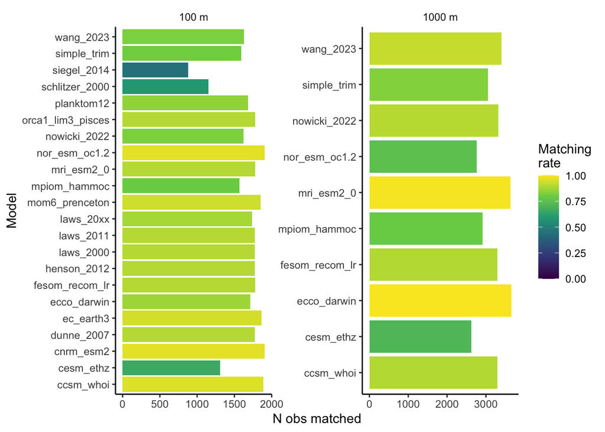

```r
# Matching validation by model
validation_summary <- match_obs %>%
  group_by(model, target_depth) %>%
  summarise(
    total_obs = n(),
    failed_alignment = sum(is.na(lon_grid) | is.na(lat_grid)),
    failed_match = sum(is.na(poc_flux)),
    success_match = total_obs - failed_match,
    success_rate = success_match / total_obs,
    .groups = "drop"
  )

# Plot it
ggplot(validation_summary) +
  geom_col(aes(y = model, x = success_match, fill = success_rate)) +
  scale_fill_viridis_c(limits = c(0, 1)) +
  labs(x = "N obs matched", y = "Model", fill = "Matching\nrate") +
  facet_wrap(~target_depth, ncol = 2, scales = "free", labeller = labeller(target_depth = function(x) paste0(x, " m"))) +
  theme_classic() +
  theme(strip.background = element_blank())
```

Match-up is rather good, except for Siegel 2014, Schlitzer 2000 and cesm_ethz at 100 m. This is caused by the coverage (or lack of coverage) of models. Let’s have a quick look at unmatched observations for both models.

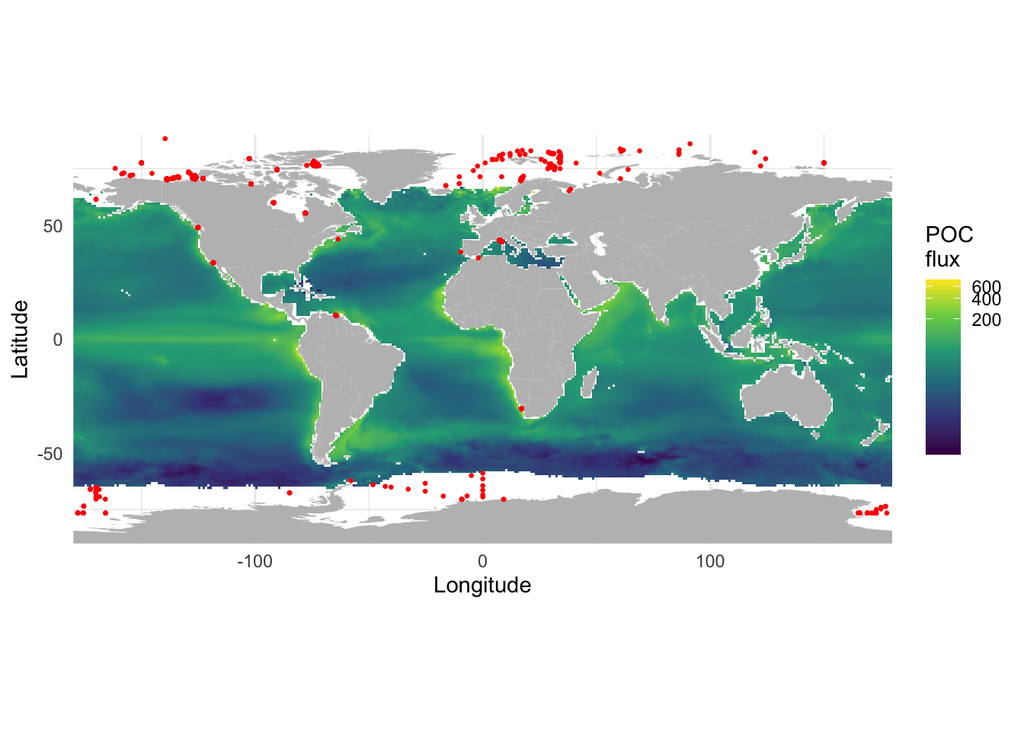

```r
ggplot() +
  geom_polygon(data = world, aes(x = lon, y = lat, group = group), fill = "grey") +
  geom_raster(data = df_models |> filter(model == "siegel_2014"), aes(x = lon, y = lat, fill = poc_flux)) +
  geom_point(data = match_obs |> filter(model == "siegel_2014" & is.na(poc_flux)), aes(x = lon, y = lat), size = 0.5, colour = "red") +
  scale_fill_viridis_c(na.value = NA, trans = "log1p") +
  labs(x = "Longitude", y = "Latitude", fill = "POC\nflux") +
  coord_quickmap(expand = 0)
```

Unmatched observations are indeed in location not covered by Siegel 2014.

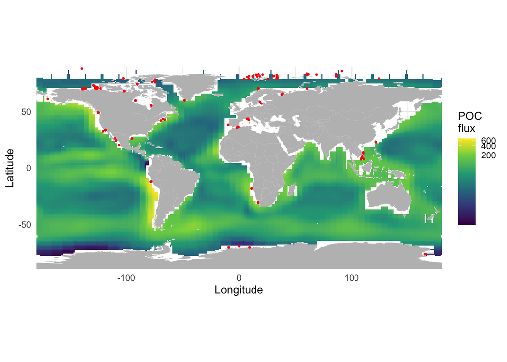

```r
ggplot() +
  geom_polygon(data = world, aes(x = lon, y = lat, group = group), fill = "grey") +
  geom_raster(data = df_models |> filter(model == "schlitzer_2000"), aes(x = lon, y = lat, fill = poc_flux)) +
  geom_point(data = match_obs |> filter(model == "schlitzer_2000" & is.na(poc_flux)), aes(x = lon, y = lat), size = 0.5, colour = "red") +
  scale_fill_viridis_c(na.value = NA, trans = "log1p") +
  labs(x = "Longitude", y = "Latitude", fill = "POC\nflux") +
  coord_quickmap(expand = 0)
```

Same for Schlitzer 2000.

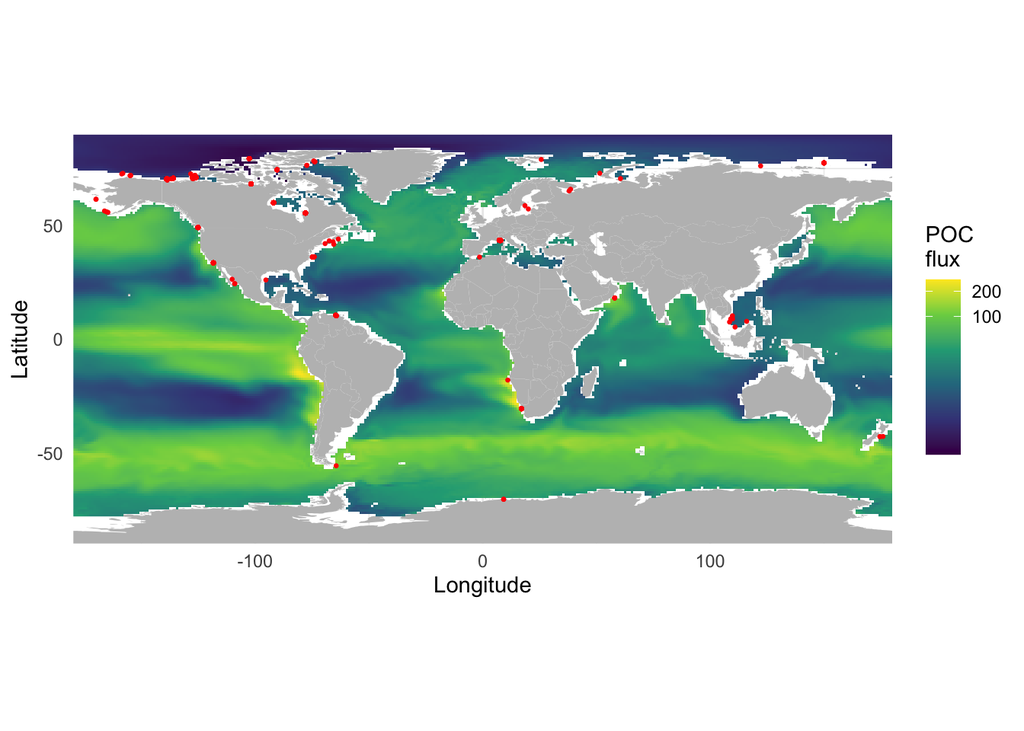

```r
ggplot() +
  geom_polygon(data = world, aes(x = lon, y = lat, group = group), fill = "grey") +
  geom_raster(data = df_models |> filter(model == "cesm_ethz"& depth == 100), aes(x = lon, y = lat, fill = poc_flux)) +
  geom_point(data = match_obs |> filter(model == "cesm_ethz" & target_depth == 100 & is.na(poc_flux)), aes(x = lon, y = lat), size = 0.5, colour = "red") +
  scale_fill_viridis_c(na.value = NA, trans = "log1p") +
  labs(x = "Longitude", y = "Latitude", fill = "POC\nflux") +
  coord_quickmap(expand = 0)
```

Same for cesm_ethz.

## Reformat results

Reshape results to have one column per model.

```r
# Separate results by target depth
match_obs_100 <- match_obs %>% filter(target_depth == 100)
match_obs_1000 <- match_obs %>% filter(target_depth == 1000)

# First we need the list of models for each target depth
mod_list_100 <- match_obs_100 %>%
  filter(!is.na(poc_flux)) %>%
  pull(model) %>%
  unique()
mod_list_1000 <- match_obs_1000 %>%
  filter(!is.na(poc_flux)) %>%
  pull(model) %>%
  unique()

# Convert to a wider format (one column per model)
match_obs_wide_100 <- match_obs_100 %>%
  # Delete model metadata
  select(-c(lon_grid, lat_grid, colour, type)) %>%
  # Keep only listed models for that depth
  filter(model %in% mod_list_100) %>%
  # Make wider
  pivot_wider(
    values_from = poc_flux,
    names_from = model,
    values_fill = NA
  )
match_obs_wide_1000 <- match_obs_1000 %>%
  # Delete model metadata
  select(-c(lon_grid, lat_grid, colour, type)) %>%
  # Keep only listed models for that depth
  filter(model %in% mod_list_1000) %>%
  # Make wider
  pivot_wider(
    values_from = poc_flux,
    names_from = model,
    values_fill = NA
  )
```

## Save results

```r
write_csv(match_obs_wide_100, file = "data/06.poc_flux_match_100.csv")
write_csv(match_obs_wide_1000, file = "data/06.poc_flux_match_1000.csv")
```